# Conservation_glm_md.R

Amy  
Mon Oct 29 15:01:51 2018

```r
library(ggplot2)
library(tidyr)
library(tidyverse)
library(arm)
library(gridExtra) #To allow arranging multiple plots
library(dplyr)
library(rstan) #for extract function
library(rstanarm)
options(mc.cores = parallel::detectCores())
theme_set(theme_grey()) #rstanarm overrides default ggplot theme: set it back



Conservation_data<-read.csv("Individual_project/Conservation_data.csv",header=TRUE)
names(Conservation_data)
```

```
##  [1] "County_ID_FIPS"
##  [2] "State_FIPS"
##  [3] "County_FIPS"
##  [4] "County_ID_EXCEL"
##  [5] "County_Name"
##  [6] "State_Name"
##  [7] "Area_of_County_ha"
##  [8] "Lat_County_Centroid_Y"
##  [9] "Long_County_Centroid_X"
## [10] "Count_GapStatus1_PAs"
## [11] "Area_GapStatus1_PAs_ha"
## [12] "Count_GapStatus2_PAs"
## [13] "Area_GapStatus2_PAs_ha"
## [14] "Count_GapStatus3_PAs"
## [15] "Area_GapStatus3_PAs_ha"
```

[output cut: 59 more lines]

```r
dat<-Conservation_data[,c(1,2,3,5,6,11,13,15,17)]
head(dat)
```

```
##   County_ID_FIPS State_FIPS County_FIPS   County_Name    State_Name
## 1          25025         25          25       Suffolk Massachusetts
## 2           6075          6          75 San Francisco    California
## 3          35028         35          28    Los Alamos    New Mexico
## 4          51013         51          13     Arlington      Virginia
## 5          27123         27         123        Ramsey     Minnesota
## 6          22071         22          71       Orleans     Louisiana
##   Area_GapStatus1_PAs_ha Area_GapStatus2_PAs_ha Area_GapStatus3_PAs_ha
## 1                  0.000           6.207472e+04            16726.48159
## 2               6130.509           3.748194e+04            20888.93169
## 3               3950.024           4.856699e-01            15150.86564
## 4                  0.000           1.398152e+01               69.85727
## 5                  0.000           1.329744e+02             3811.05186
## 6              10156.619           2.569581e+02                0.00000
##   Area_GapStatus4_PAs_ha
## 1            1371.759112
## 2             612.651704
## 3           11241.495440
## 4             663.095872
## 5               1.731649
## 6             711.709482
```

```r
#View(dat)
colnames(dat)[6:9]<-c("G1","G2","G3","G4")
head(dat)
```

```
##   County_ID_FIPS State_FIPS County_FIPS   County_Name    State_Name
## 1          25025         25          25       Suffolk Massachusetts
## 2           6075          6          75 San Francisco    California
## 3          35028         35          28    Los Alamos    New Mexico
## 4          51013         51          13     Arlington      Virginia
## 5          27123         27         123        Ramsey     Minnesota
## 6          22071         22          71       Orleans     Louisiana
##          G1           G2          G3           G4
## 1     0.000 6.207472e+04 16726.48159  1371.759112
## 2  6130.509 3.748194e+04 20888.93169   612.651704
## 3  3950.024 4.856699e-01 15150.86564 11241.495440
## 4     0.000 1.398152e+01    69.85727   663.095872
## 5     0.000 1.329744e+02  3811.05186     1.731649
## 6 10156.619 2.569581e+02     0.00000   711.709482
```

```r
dat[,6:9]<-round(dat[,6:9],digits=3)
dat[, 6:9][dat[, 6:9] == 0] <- NA
head(dat)
```

```
##   County_ID_FIPS State_FIPS County_FIPS   County_Name    State_Name
## 1          25025         25          25       Suffolk Massachusetts
## 2           6075          6          75 San Francisco    California
## 3          35028         35          28    Los Alamos    New Mexico
## 4          51013         51          13     Arlington      Virginia
## 5          27123         27         123        Ramsey     Minnesota
## 6          22071         22          71       Orleans     Louisiana
##          G1        G2        G3        G4
## 1        NA 62074.724 16726.482  1371.759
## 2  6130.509 37481.940 20888.932   612.652
## 3  3950.024     0.486 15150.866 11241.495
## 4        NA    13.982    69.857   663.096
## 5        NA   132.974  3811.052     1.732
## 6 10156.619   256.958        NA   711.709
```

```r
###################################################################here: Should be 9327
n<-NULL
  for (i in 6:9) {
    n[i]<-length(dat[,i][!is.na(dat[,i])])
  }
  sum<-sum(n,na.rm=TRUE)
sum
```

```
## [1] 9327
```

```r
#Length should be:
Correct_length<-paste("Length Should Be:",sum)
Correct_length
```

```
## [1] "Length Should Be: 9327"
```

```r
#Stacking
library(reshape2)
dat1 <- melt(dat, id.vars=1:5, na.rm=TRUE, value.name="PA_ha")
head(dat1)
```

```
##    County_ID_FIPS State_FIPS County_FIPS   County_Name   State_Name
## 2            6075          6          75 San Francisco   California
## 3           35028         35          28    Los Alamos   New Mexico
## 6           22071         22          71       Orleans    Louisiana
## 7           34013         34          13         Essex   New Jersey
## 9           12103         12         103      Pinellas      Florida
## 10          42101         42         101  Philadelphia Pennsylvania
##    variable     PA_ha
## 2        G1  6130.509
## 3        G1  3950.024
## 6        G1 10156.619
## 7        G1   116.977
## 9        G1  7907.001
## 10       G1     9.856
```

```r
#View(dat1)
names(dat1)
```

```
## [1] "County_ID_FIPS" "State_FIPS"     "County_FIPS"    "County_Name"
## [5] "State_Name"     "variable"       "PA_ha"
```

```r
colnames(dat1)[6]<-"Gap_Status"
head(dat1)
```

```
##    County_ID_FIPS State_FIPS County_FIPS   County_Name   State_Name
## 2            6075          6          75 San Francisco   California
## 3           35028         35          28    Los Alamos   New Mexico
## 6           22071         22          71       Orleans    Louisiana
## 7           34013         34          13         Essex   New Jersey
## 9           12103         12         103      Pinellas      Florida
## 10          42101         42         101  Philadelphia Pennsylvania
##    Gap_Status     PA_ha
## 2          G1  6130.509
## 3          G1  3950.024
## 6          G1 10156.619
## 7          G1   116.977
## 9          G1  7907.001
## 10         G1     9.856
```

```r
length(dat1$Gap_Status)
```

```
## [1] 9327
```

```r
Correct_length
```

```
## [1] "Length Should Be: 9327"
```

```r
#View(dat1)

# Truncating data at 1 hectare, because less than one is probably an error or unimportant:
data<-filter(dat1, PA_ha>=1) # Sanity check
sc<-filter(dat1, PA_ha<1)
(length(data$PA_ha) + length(sc$PA_ha))==length(dat1$PA_ha)
```

```
## [1] TRUE
```

```r
Correct_length2<-paste("Length Should Be:",length(data$PA_ha))
rm(data,sc) # Cleaning up
dat1<-filter(dat1, PA_ha>=1)
length(dat1$PA_ha)
```

```
## [1] 9165
```

```r
Correct_length2
```

```
## [1] "Length Should Be: 9165"
```

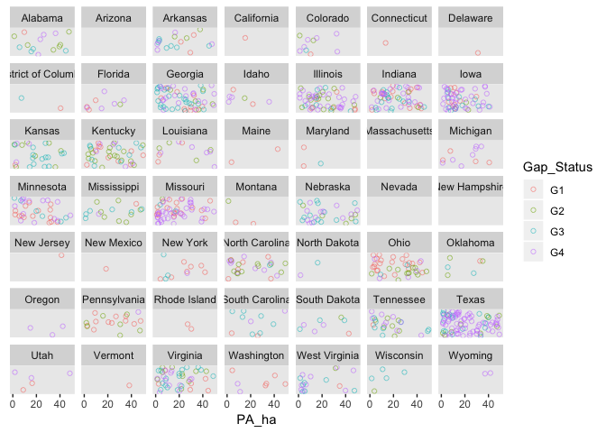

```r
# Plots all states with hectares of protected area by gap status
dat1 %>%
  mutate(yjit=jitter(0*PA_ha)) %>%
  ggplot() +
  geom_point(mapping = aes(x=PA_ha,col=Gap_Status,y=yjit),shape=1,alpha=0.5) +
  facet_wrap(facets = ~ State_Name) +
  scale_x_continuous(breaks=c(0,20,40),limits=c(0,50)) +
  theme(axis.text.y=element_blank(),axis.ticks.y=element_blank(),
        axis.title.y=element_blank(),panel.grid=element_blank())
```

```r
# How many samples per gap status?
n<-NULL
for (i in 1:4) {
  n[i]<-length(dat1$Gap_Status[dat1$Gap_Status==paste("G",i,sep="")])
}
names(n)<-c("G1","G2","G3","G4")
n
```

```
##   G1   G2   G3   G4
## 1256 2793 2414 2702
```

```r
head(dat1)
```

```
##   County_ID_FIPS State_FIPS County_FIPS   County_Name   State_Name
## 1           6075          6          75 San Francisco   California
## 2          35028         35          28    Los Alamos   New Mexico
## 3          22071         22          71       Orleans    Louisiana
## 4          34013         34          13         Essex   New Jersey
## 5          12103         12         103      Pinellas      Florida
## 6          42101         42         101  Philadelphia Pennsylvania
##   Gap_Status     PA_ha
## 1         G1  6130.509
## 2         G1  3950.024
## 3         G1 10156.619
## 4         G1   116.977
## 5         G1  7907.001
## 6         G1     9.856
```

```r
dat1 %>%
  group_by(State_Name) %>%
  summarize(sample_size=n()) %>%
  arrange(-sample_size)
```

```
## # A tibble: 49 x 2
##    State_Name     sample_size
##    <fct>                <int>
##  1 Texas                  508
##  2 Georgia                445
##  3 Virginia               387
##  4 Illinois               345
##  5 Missouri               307
##  6 Kentucky               303
##  7 North Carolina         303
##  8 Ohio                   301
##  9 Indiana                291
## 10 Minnesota              291
## # ... with 39 more rows
```

We see 8 State with more than 300 protected areas sampled. Let's extract these (using `filter()`) to get a better sense of how area of PA distributions within State might vary between State. We'll also restrict to data from the largest gap status = G2

```r
names(dat1)
```

```
## [1] "County_ID_FIPS" "State_FIPS"     "County_FIPS"    "County_Name"
## [5] "State_Name"     "Gap_Status"     "PA_ha"
```

```r
lrgst8State_G2 <- dat1 %>%
  group_by(State_Name) %>%
  filter(n() > 300,Gap_Status=="G2")
```

Histograms for the eight states.

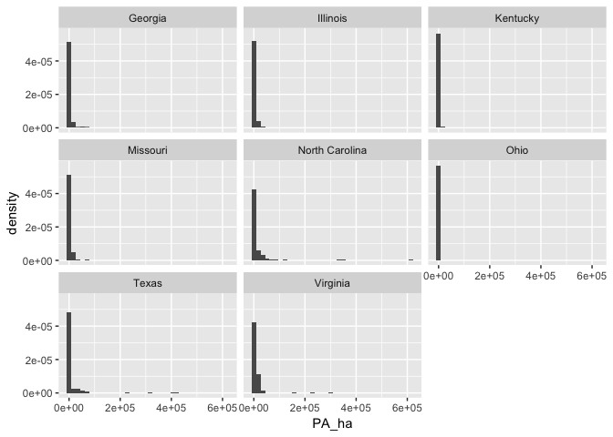

```r
ggplot(data=lrgst8State_G2) +
  geom_histogram(mapping = aes(x=PA_ha,y=stat(density)),bins=36) +
  facet_wrap(facets = ~ State_Name)
```

```r
# All Gap statuses
names(dat1)
```

```
## [1] "County_ID_FIPS" "State_FIPS"     "County_FIPS"    "County_Name"
## [5] "State_Name"     "Gap_Status"     "PA_ha"
```

```r
lrgst8State_all <- dat1 %>%
  group_by(State_Name) %>%
  filter(n() > 300)
```

Histograms for the eight states.

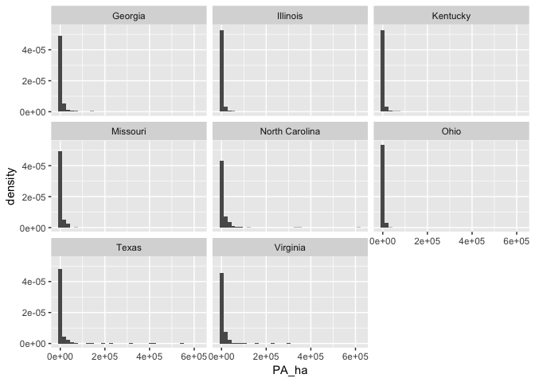

```r
ggplot(data=lrgst8State_all) +
  geom_histogram(mapping = aes(x=PA_ha,y=stat(density)),bins=36) +
  facet_wrap(facets = ~ State_Name)
```

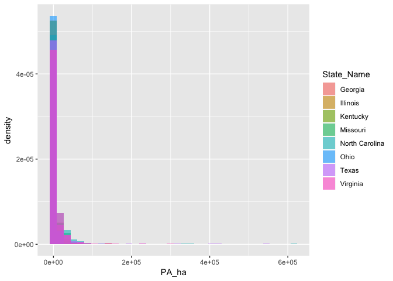

```r
# pretty concentrated around small protected areas

# Overlapping histograms:
ggplot(data=lrgst8State_all) +
  geom_histogram(mapping = aes(x=PA_ha,y=stat(density),fill=State_Name),
                 position="identity",bins=36,alpha=0.6)
```

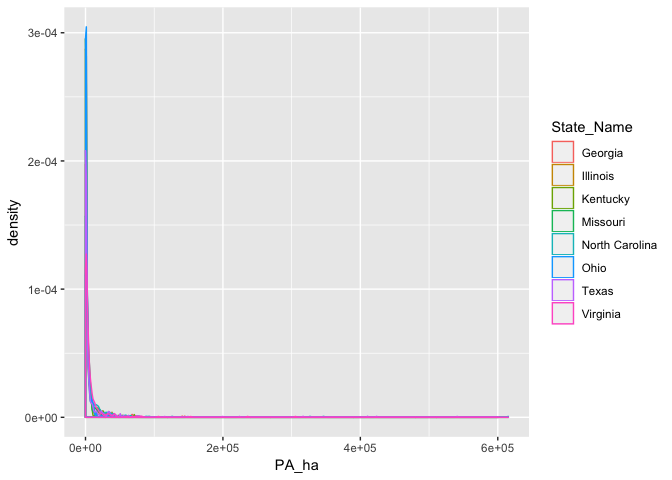

```r
#Density plot:
ggplot(data=lrgst8State_all) +
  geom_density(mapping = aes(x=PA_ha,col=State_Name))
```

```r
########## All those plots with log transformation:#########################
```

Histograms for the eight states.

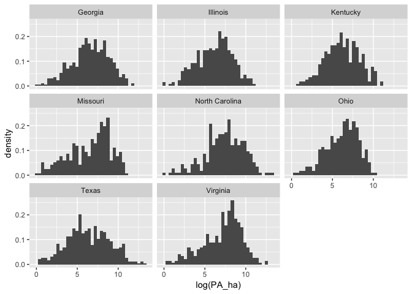

```r
ggplot(data=lrgst8State_all) +
  geom_histogram(mapping = aes(x=log(PA_ha),y=stat(density)),bins=36) +
  facet_wrap(facets = ~ State_Name)
```

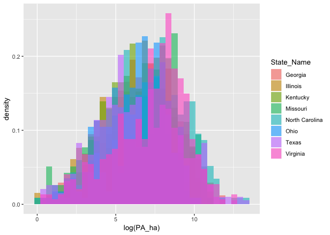

```r
# Overlapping histograms:
ggplot(data=lrgst8State_all) +
  geom_histogram(mapping = aes(x=log(PA_ha),y=stat(density),fill=State_Name),
                 position="identity",bins=36,alpha=0.6)
```

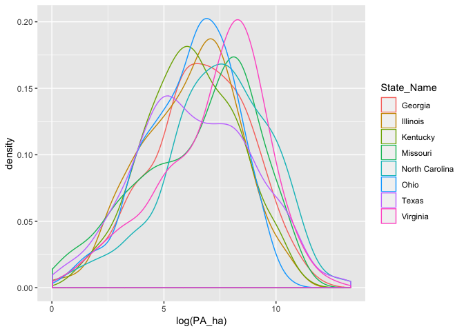

```r
#Density plot:
ggplot(data=lrgst8State_all) +
  geom_density(mapping = aes(x=log(PA_ha),col=State_Name))
```

```r
# So, definitely want to log transform:
dat1<-mutate(dat1,log_PA_ha=log(PA_ha))
head(dat1)
```

```
##   County_ID_FIPS State_FIPS County_FIPS   County_Name   State_Name
## 1           6075          6          75 San Francisco   California
## 2          35028         35          28    Los Alamos   New Mexico
## 3          22071         22          71       Orleans    Louisiana
## 4          34013         34          13         Essex   New Jersey
## 5          12103         12         103      Pinellas      Florida
## 6          42101         42         101  Philadelphia Pennsylvania
##   Gap_Status     PA_ha log_PA_ha
## 1         G1  6130.509  8.721033
## 2         G1  3950.024  8.281477
## 3         G1 10156.619  9.225881
## 4         G1   116.977  4.761977
## 5         G1  7907.001  8.975504
## 6         G1     9.856  2.288080
```

Take a look at the transformed data in those 8 states First make a data frame with the estimated normal distribution for the 8 states Summary statistics for 8 states

```r
summ8State <-
  dat1 %>%
  group_by(State_Name) %>%
  filter(n() > 300,Gap_Status=="G2") %>%
  summarize(mean=mean(log_PA_ha),sd=sd(log_PA_ha),min=min(log_PA_ha),max=max(log_PA_ha))
```

```r
norm_df <- NULL
for ( i in 1:8 ) {
  x <- seq(summ8State$min[i],summ8State$max[i],length.out = 100)
  y <- dnorm(x, summ8State$mean[i], summ8State$sd[i])
  norm_df <- rbind(norm_df,data.frame(x,y,State_Name=summ8State$State_Name[i]))
}
rm(x,y) #clean up
```

Now plot the transformed data with density smoother (blue) and fitted normal (red). The log transformation seems very good:

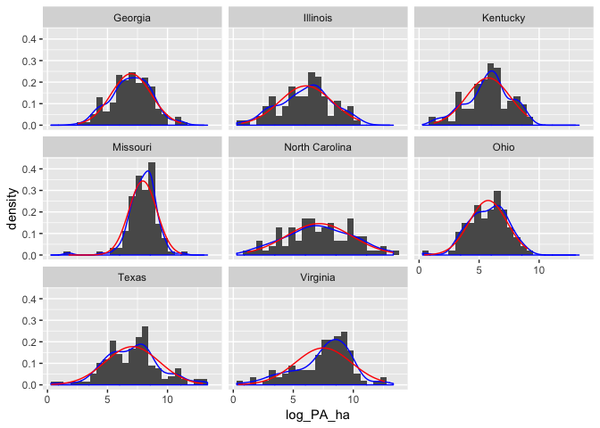

```r
dat1 %>%
  group_by(State_Name) %>%
  filter(n() > 300,Gap_Status=="G2") %>%
  ggplot() +
  geom_histogram(mapping = aes(x=log_PA_ha,y=stat(density)),bins=25) +
  geom_density(mapping = aes(x=log_PA_ha),col="blue") +
  geom_line(data=norm_df, mapping = aes(x=x,y=y),col="red") +
  facet_wrap(facets = ~ State_Name)
```

And now for the whole dataset split by gap status It is simple to modify the above code to group by gap status instead.

```r
summ_byGap_Status <-
  dat1 %>%
  group_by(Gap_Status) %>%
  summarize(mean=mean(log_PA_ha),sd=sd(log_PA_ha),min=min(log_PA_ha),max=max(log_PA_ha))
```

Normal fitted for 4 Gap Statuses

```r
norm_df <- NULL
for ( i in 1:4 ) {
  x <- seq(summ_byGap_Status$min[i],summ_byGap_Status$max[i],length.out = 100)
  y <- dnorm(x, summ_byGap_Status$mean[i], summ_byGap_Status$sd[i])
  norm_df <- rbind(norm_df,data.frame(x,y,Gap_Status=summ_byGap_Status$Gap_Status[i]))
}
rm(x,y)
```

Now plot the transformed data with density smoother (blue) and fitted normal (red).

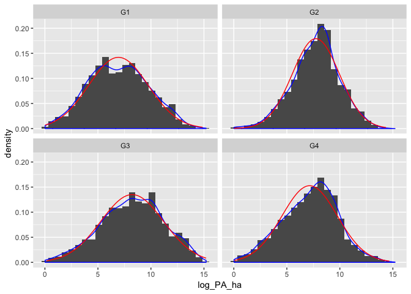

```r
dat1 %>%
  group_by(Gap_Status) %>%
  ggplot() +
  geom_histogram(mapping = aes(x=log_PA_ha,y=stat(density)),bins=25) +
  geom_density(mapping = aes(x=log_PA_ha),col="blue") +
  geom_line(data=norm_df, mapping = aes(x=x,y=y),col="red") +
  facet_wrap(facets = ~ Gap_Status)
```

```r
# Log Transformation works well
```

Start by converting State_Name to a factor

```r
dat1 <- mutate(dat1,State_Name=factor(State_Name))
```

#### Complete pooling

In this case, complete pooling is just the overall mean. That is, we omit any data structure or grouping variables.

```r
poolmean <- mean(dat1$log_PA_ha)
poolmean
```

```
## [1] 7.584689
```

```r
cp_pred_df <- data.frame(poolmean) #df for use with ggplot
```